# Transforming Google Analytics 4 (GA4) Data into Actionable Insights with SQL + Power BI

How to flatten nested data structures and extract minimal event data for Power BI modeling.

SQL

PowerBi

Author

Skylar Carroll

Published

March 8, 2025

This project began with a question, “How can we flatten and extract minimal GA4 data to produce a light-weight semantic model in Power BI?”

GA4’s use of STRUCT and ARRAY nested data types enables efficient storage of complex, hierarchical user interactions but they require careful handling for querying and extraction. Flattening event data multiplies the number of rows for any given user session which could result in millions of rows of unused data.

However, an effective, high-level Power BI dashboard for marketing analytics, only requires select fields.

**Note: Marketing metrics like CPC, ROAS etc. aren’t calculable with the GA4 sample e-commerce dataset.

## Key Challenges and Solutions

- **Data Extraction:** The SQL queries utilize `UNNEST`, `LEFT JOIN`, and subqueries to flatten ARRAY and STRUCT data. This multiplies the number of rows per session, so select your data strategically.
- **Data Selection**: A list of all required attributes should be created before beginning to write the SQL. It is critical to understand the definitions of each attribute and what they represent. GA4 documentation should be referenced carefully, and audits conducted before launching any live service dashboard.
- **Data Transformation:** It’s best practice to transform and clean your data in SQL as much as possible to create meaningful insights. Query folding in Power Query doesn’t always work and too many transformations can create performance bottlenecks. Let the source do the heavy lifting.
- **Semantic Modeling:** Create a simplified semantic model suitable for marketing analysis, focusing on user sessions, purchase details, and item information. Using parameters as start and end dates allow for easy updates.

## SQL Queries

Here’s a breakdown of the SQL queries:

### 1. Session-Level Data Extraction

- This query extracts session-level information, including timestamps, user IDs, page views, and traffic sources. It also creates unique keys for session analysis and cleans page titles for better readability.

```sql
-- Define a CTE to extract session-level data from GA4 event logs
WITH session_level AS (
  SELECT
    event_date, -- The date of the event
    extract(
      datetime
      FROM
        timestamp_micros(event_timestamp)
    ) AS event_timestamp, -- Convert event timestamp to a readable datetime format
    user_pseudo_id,

    -- Create a unique join key for session-level analysis by combining user ID, session ID, timestamp, and event name
    concat(
      user_pseudo_id,
      (
        SELECT
          value.int_value
        FROM
          unnest(event_params)
        WHERE
          KEY = 'ga_session_id'
      ),
      event_timestamp,
      event_name
    ) AS join_key,

    -- Create a session key using user ID and session ID
    concat(
      user_pseudo_id,
      (
        SELECT
          value.int_value
        FROM
          unnest(event_params)
        WHERE
          KEY = 'ga_session_id'
      )
    ) AS session_key,
    event_name,

    -- Extract the page title from event parameters
    (
      SELECT
        value.string_value
      FROM
        unnest(event_params)
      WHERE
        KEY = 'page_title'
    ) AS page_title,

    -- Extract the page URL from event parameters
    (
      SELECT
        value.string_value
      FROM
        unnest(event_params)
      WHERE
        KEY = 'page_location'
    ) AS page_location,

    -- Extract engagement time (in milliseconds) from event parameters
    (
      SELECT
        value.int_value
      FROM
        unnest(event_params)
      WHERE
        KEY = 'engagement_time_msec'
    ) AS event_engagement_time_msec,

    -- Extract traffic source information (where the user came from)
    traffic_source.name AS traffic_source_name,
    traffic_source.medium AS traffic_source_medium,
    traffic_source.source AS traffic_source_source,
    device.category AS device
  FROM
    -- change this to your google analytics 4 export location in bigquery
    `bigquery-public-data.ga4_obfuscated_sample_ecommerce.events_*`
  WHERE
    _table_suffix BETWEEN '20201231' -- Change the dates to your parameters in Power Query M code
    AND '20210131'
),

-- Define another CTE to clean and standardize page titles
page_clean AS (
  SELECT
    *
  EXCEPT
    (page_title),

    -- Clean the page_title field
    CASE WHEN page_title IS NULL THEN REPLACE(
      REGEXP_EXTRACT(
        REGEXP_REPLACE(trim(page_location), r '/$', ''),
        r '[^/]+$'
      ),
      r '[+-]',
      ' '
    )
    -- Extract last part of URL as a fallback page title, replacing special characters
    WHEN trim(page_location) = trim("https://shop.googlemerchandisestore.com/New/") THEN "New" WHEN trim(page_location) = trim(
      "https://shop.googlemerchandisestore.com/details/New/New/GGL1720_Google Notabag - Blue"
    ) THEN "Google Notabag - Blue" WHEN trim(page_location) = trim(
      "https://shop.googlemerchandisestore.com/details/New/New/GGL1720_Google"
    ) THEN "GGL1720_Google" WHEN trim(page_location) = trim(
      "https://shop.googlemerchandisestore.com/google+redesign/apparel/google+kirkland+campus+unisex+tee"
    ) THEN "google+kirkland+campus+unisex+tee" ELSE page_title -- Keep the original page title if available
    END AS page_title_cleaned
  FROM
    session_level
)
SELECT
  *
FROM
  page_clean
```

### 2. User-Level Aggregation

- This query aggregates user-level data, such as lifetime value (LTV), country, and region.

```sql
-- Aggregate user-level data
SELECT
  user_pseudo_id, -- Anonymous user identifier

  -- Calculate the average lifetime value (LTV) revenue per user
  AVG(user_ltv.revenue) AS ltv,

  -- Retrieve the latest currency associated with the user's LTV
  MAX(user_ltv.currency) AS ltv_currency,

  -- Get the most recent country associated with the user
  MAX(geo.country) AS country,

  -- Get the most recent region (state/province) associated with the user
  MAX(geo.region) AS region
FROM
  -- Replace this with your GA4 BigQuery export table
  `bigquery-public-data.ga4_obfuscated_sample_ecommerce.events_*`
WHERE
  -- Filter for events within the specified date range
  _table_suffix BETWEEN '20201231' -- Change the dates to your parameters in Power Query M code
  AND '20210131'
GROUP BY
  user_pseudo_id; -- Aggregate data at the user level
```

### 3. Item Details

- This query retrieves item-related information.

```sql
-- Extract and aggregate item details
SELECT
  i.item_id, -- Unique identifier for the item
  i.item_name, -- Name of the item

  -- Retrieve the most recent category associated with the item
  MAX(i.item_category) AS category
FROM
  -- Replace this with your GA4 BigQuery export table
  `bigquery-public-data.ga4_obfuscated_sample_ecommerce.events_*`,

  -- Expand the nested 'items' array to extract individual item details
  UNNEST(items) AS i
GROUP BY
  i.item_id, -- Group by item ID to aggregate item-level data
  i.item_name; -- Group by item name to maintain unique item records
```

### 4. Purchase - event level

- This query extracts details of each purchase event.

```sql
--purchase

SELECT concat(user_pseudo_id,
                (SELECT value.int_value
                 FROM unnest(event_params)
                 WHERE KEY = 'ga_session_id'),event_timestamp, event_name) AS join_key,
       ecommerce.transaction_id,
       ecommerce.total_item_quantity,
       ecommerce.purchase_revenue_in_usd,
       ecommerce.purchase_revenue,
       ecommerce.refund_value_in_usd,
       ecommerce.refund_value,
       ecommerce.shipping_value_in_usd,
       ecommerce.shipping_value,
       ecommerce.tax_value_in_usd,
       ecommerce.tax_value,
       ecommerce.unique_items
FROM -- change this to your google analytics 4 export location in bigquery
 `bigquery-public-data.ga4_obfuscated_sample_ecommerce.events_*`
WHERE event_name = 'purchase'
  AND _table_suffix BETWEEN '20201231' AND '20210131' -- Change the dates to your parameters in Power Query M code
```

### 5. Purchase Details - Item level

- This query extracts detailed information about purchased items, including item IDs, names, prices, and quantities.

```sql
--purchase details

SELECT event_timestamp,
       concat(user_pseudo_id,
                (SELECT value.int_value
                 FROM unnest(event_params)
                 WHERE KEY = 'ga_session_id'),event_timestamp, event_name) AS join_key,
       i.item_id,
       i.item_name,
       i.item_brand,
       i.item_variant,
       i.item_category,
       i.coupon,
       i.affiliation,
       i.location_id,
       i.item_list_id,
       i.item_list_name,
       i.item_list_index,
       i.promotion_id,
       i.promotion_name,
       i.creative_name,
       i.creative_slot,
       i.price_in_usd,
       i.price,
       i.quantity,
       i.item_revenue_in_usd,
       i.item_revenue,
       i.item_refund_in_usd
FROM -- change this to your google analytics 4 export location in bigquery
 `bigquery-public-data.ga4_obfuscated_sample_ecommerce.events_*`
LEFT JOIN unnest(items) i
WHERE event_name = 'purchase'
  AND _table_suffix BETWEEN '20201231' AND '20210131' -- Change the dates to your parameters in Power Query M code
```

### 6. Session Analysis

- This query calculates session metrics like session duration, engagement, and unique page views.

```sql
--sessions
WITH prep AS
  (SELECT event_timestamp,
          concat(user_pseudo_id,
                   (SELECT value.int_value
                    FROM unnest(event_params)
                    WHERE KEY = 'ga_session_id')) AS session_key,
          coalesce(cast(
                          (SELECT value.string_value
                           FROM unnest(event_params)
                           WHERE KEY = 'session_engaged') AS int), 0) AS session_engaged,
          count(DISTINCT
                  (SELECT value.string_value
                   FROM unnest(event_params)
                   WHERE KEY = 'page_location')) over(PARTITION BY user_pseudo_id,
                                                        (SELECT value.int_value
                                                         FROM unnest(event_params)
                                                         WHERE KEY = 'ga_session_id')) AS unique_page_views,

     (SELECT value.int_value
      FROM unnest(event_params)
      WHERE KEY = 'engagement_time_msec') AS session_engagement_time_msec
   FROM -- change this to your google analytics 4 export location in bigquery
 `bigquery-public-data.ga4_obfuscated_sample_ecommerce.events_*`
   WHERE _table_suffix BETWEEN '20201231' AND '20210131')
SELECT max(event_timestamp) - min(event_timestamp) AS session_duration_msec,
       session_key,
       max(session_engaged) AS session_engaged,
       max(unique_page_views) AS upv,
       sum(session_engagement_time_msec) AS session_engagement_time_msec
FROM prep
GROUP BY session_key
```

## Semantic Model

The extracted and transformed data can be used to build a semantic model in Power BI, enabling interactive analysis and reporting.

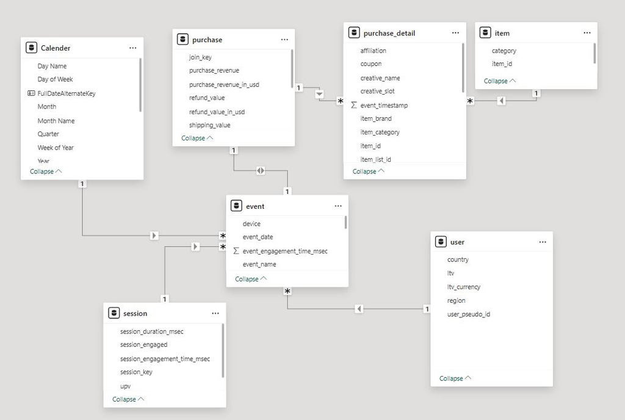

Semantic Model